# Complex Networks - Exercises 3

Student: Jorge Augusto Salgado Salhani. #USP: 8927418

Student: Nicoly Soares de Almeida. #USP: 8059063

```python
import numpy as np
import networkx as nx
import matplotlib.pyplot as plt
from tqdm import tqdm as tqdm
import pandas as pd
from scipy import stats

import warnings
warnings.filterwarnings("ignore")
```

# Question 1

At first step for this question we need generate some network based on the following methods: Erdos-Renyi (ER), Watts-Strogatz (WS) and Barabasi-Albert (BA). Once they are distinct networks, we can draw variated positional layouts already built-in networkx methods in order to better represent each of which.

```python
def draw_variated_layout(G):
    d = dict(G.degree())
    pos = nx.fruchterman_reingold_layout(G);
    plt.figure(figsize=(8,8));
    plt.axis("off");
    plt.title("Fruchterman-Reingold layout", fontsize=18)
    nx.draw_networkx(G, pos=pos, with_labels=False, width=.4,
                     nodelist=d.keys(), node_size=[v * 8 for v in d.values()])
    plt.show()

    plt.figure(figsize=(8,8));
    plt.axis("off");
    plt.title("Spring layout", fontsize=18)
    pos = nx.spring_layout(G)
    nx.draw_networkx(G, pos=pos, with_labels=False, width=.4,
                     nodelist=d.keys(), node_size=[v * 8 for v in d.values()])
    plt.show();

    plt.figure(figsize=(8,8));
    plt.axis("off");
    plt.title("Kamada-Kawai layout", fontsize=18)
    pos = nx.kamada_kawai_layout(G)
    nx.draw_networkx(G, pos=pos, with_labels=False, width=.4,
                     nodelist=d.keys(), node_size=[v * 8 for v in d.values()])
    plt.show();

    plt.figure(figsize=(8,8));
    plt.axis("off");
    plt.title("Circular layout", fontsize=18)
    pos = nx.circular_layout(G)
    nx.draw_networkx(G, pos=pos, with_labels=False, width=.4,
                     nodelist=d.keys(), node_size=[v * 8 for v in d.values()])
    plt.show();
```

```python
def degree_distribution(G):
    """
    FUNCTION:
    Calculates the degree distribution and the probability associated with each data

    PARAMETERS:
    G: networkx graph object

    RETURN:
    tuple (kvalues, pk):  kvalues: each line segmentation for histogram-plot purpose;
                          pk: probability associated with each line segmentation

    """
    vk = dict(G.degree())
    vk = list(vk.values())
    maxk = np.max(vk)
    mink = np.min(min)
    kvalues = np.arange(0, maxk+1)
    pk = np.zeros(maxk+1)
    for k in vk:
        pk[k] = pk[k] + 1
    pk = pk/sum(pk)
    return kvalues, pk
```

## Erdos-Renyi method (ER)

This model consists in generating N nodes and conncting two of them with a given probability p. Once it consider the creation of new edges with this probability, it can be thought as a Bernoulli process. Therefore, the binomial distribution holds. Knowing that

$$ P(X=k) = \binom{N}{k}p^k (1-p)^{N-k} $$

is the probability of X (a random variable) receive the value of k with N samples, the probability of a random graph has L edges is given by

$$ \begin{equation} P(L) = \binom{\binom{N}{2}}{L} p^L (1-p)^{\frac{N(N-1)}{2} - L} \end{equation} $$

Where the binom(N,2) considers the maximum number of connections on a graph with N nodes. Also, since

$$ \binom{N}{2} = \frac{N (N-1)}{2} $$

the distribution for P(L) is analogous to the P(X=k).

```python
N = 100
av_degree = 8
p = av_degree/(N-1)
GER = nx.gnp_random_graph(N, p, seed=None, directed=False)

N = len(GER)
M = GER.number_of_nodes()
print('Number of nodes ', N)
print('Number of edges ', M)
print('Average degree ', 2*M/N)
```

```
Number of nodes  100
Number of edges  100
Average degree  2.0
```

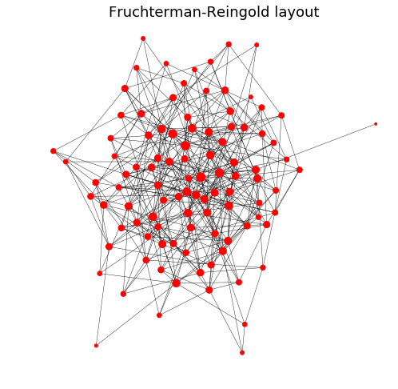

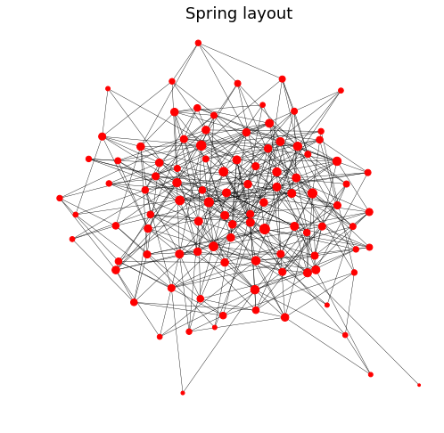

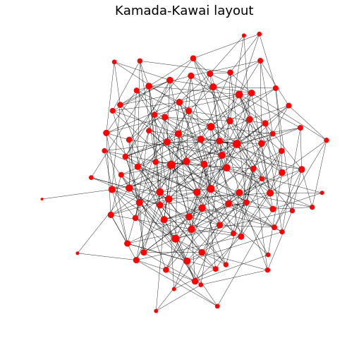

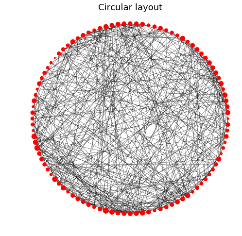

```python
draw_variated_layout(GER)
```

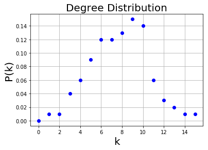

```python
ks, pk = degree_distribution(GER)

plt.figure()
plt.plot(ks, pk, 'bo', label='Data')
plt.xlabel('k', fontsize=20)
plt.ylabel('P(k)', fontsize=20)
plt.title('Degree Distribution', fontsize=20)
plt.grid(True)
```

## Watts-Strogatz method (WS)

Considering a graph with nodes already connected with each of their nearest neighbors. After each step, a link is undone with probability p and the node is rewired to another node j (chosen with uniformly distributed probability between all nodes). This consideration cannot be modeled with binomial distribution.

```python
N = 100
av_degree = 8
k = int(av_degree/2)
p = 1
GWS = nx.watts_strogatz_graph(N, k, p, seed=None)

N = len(GWS)
M = GWS.number_of_edges()
print('Number of nodes:', N)
print('Number of edges:', M)
print('Average degre:', 2*M/N)
```

```
Number of nodes: 100
Number of edges: 200
Average degre: 4.0
```

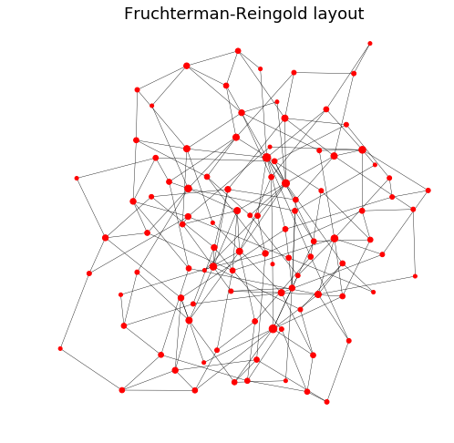

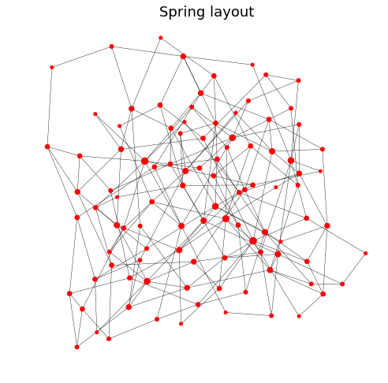

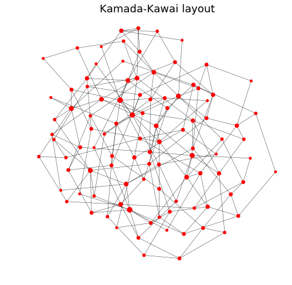

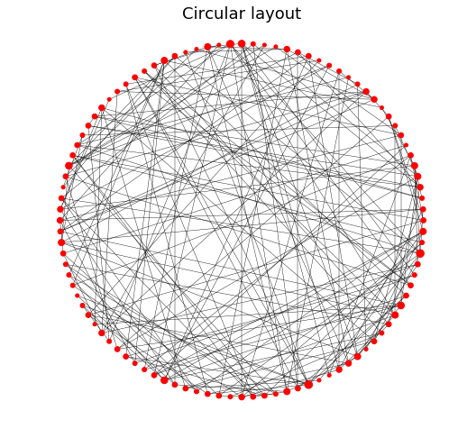

```python
draw_variated_layout(GWS)
```

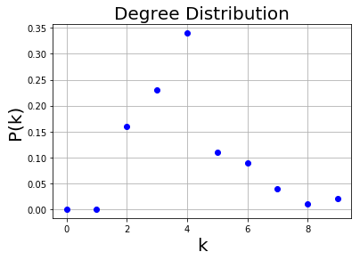

```python
ks, pk = degree_distribution(GWS)

plt.figure()
plt.plot(ks, pk, 'bo', label='Data')
plt.xlabel('k', fontsize=20)
plt.ylabel('P(k)', fontsize=20)
plt.title('Degree Distribution', fontsize=20)
plt.grid(True)
```

## Barabasi-Albert method (BA)

Finally, for Barabasi-Albert model, it is considered a preferential attachment, were each new vertex added is linked to older ones with a probability directly dependent to older node's degree. It causes the phenomenon of scale free networks, were hubs are created. Therefore, we can write the probability of attachment of the i-th node (already existent on network) to a new one as

$$ \begin{equation} P(k_i) = \frac{k_i}{\sum_j k_j} \end{equation} $$

Considering that at each time step we add one node, it arises a growth dynamic which can be modeled as

$$ \begin{equation} \frac{\partial}{\partial t} k_i \propto P(k_i) \end{equation} $$

or, as an equality

$$ \begin{equation} \frac{\partial}{\partial t} k_i = A \frac{k_i}{\sum_j k_j} \end{equation} $$

Now, after t time steps the model leads to a random network with

$$ N = t + m_0 $$

vertices, where $m_0$ is the initial amount of nodes (at t=0) and $mt$ edges, with $m \leq m_0$ the number of edges that the newer vertices will have.

So, taking into account that

$$ \begin{equation} \sum_j k_j = 2mt \end{equation} $$

for double counting the edges that were made. Also, for $A = m$, we get that

$$ \begin{equation} \frac{\partial}{\partial t} k_i = \frac{k_i}{2t} \end{equation} $$

Starting from $m$ edges at initial time,

$$ \begin{equation} k_i(t) = m \Bigg[\frac{t}{t_i}\Bigg]^{1/2} = m \Bigg[\frac{t}{t_i}\Bigg]^{\beta} \end{equation} $$

where we define $\beta = 1/2$

The phenomenom described by this model is the 'rich-get-richer', where the older nodes in time will dominate the degree distribution at the expense of the younger ones.

```python
N = 100
av_degree = 8
m = int(av_degree/2)
GBA = nx.barabasi_albert_graph(N, m)

N = len(GBA)
M = GBA.number_of_edges()
print('Number of nodes:', N)
print('Number of edges:', M)
print('Average degre:', 2*M/N)
```

```
Number of nodes: 100
Number of edges: 384
Average degre: 7.68
```

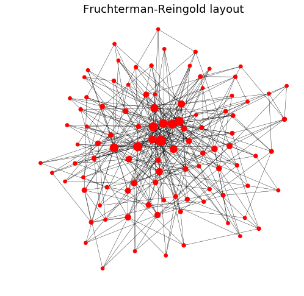

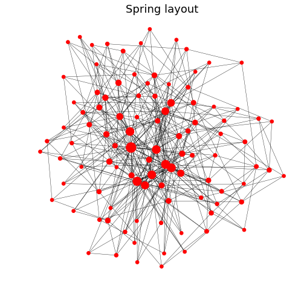

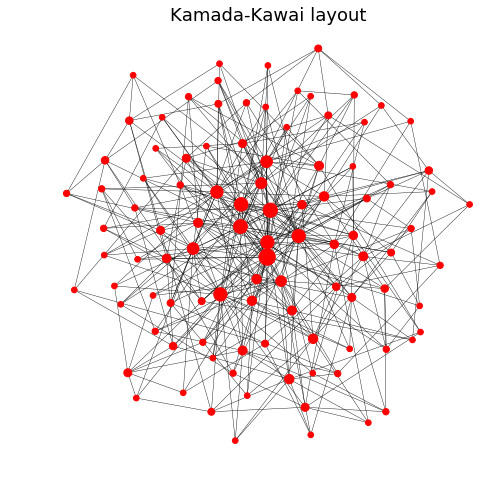

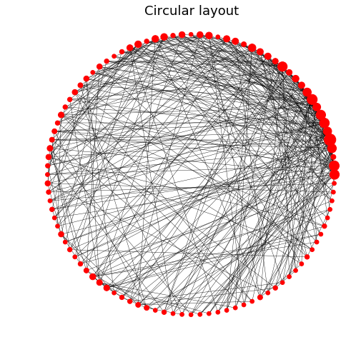

```python
draw_variated_layout(GBA)
```

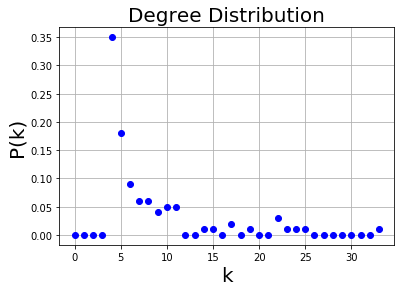

```python
ks, pk = degree_distribution(GBA)

plt.figure()
plt.plot(ks, pk, 'bo', label='Data')
plt.xlabel('k', fontsize=20)
plt.ylabel('P(k)', fontsize=20)
plt.title('Degree Distribution', fontsize=20)
plt.grid(True)
```

The probability of the degree distribution (last graphic) can also be analitically derived. Considering the probability that a vertex having connectivity $k_i(t) < k$, that is, $P(k_i(t) < k)$ can be written as

$$ P(k_i < k) = P\Big(t_i > \frac{m^2 t}{k^2} \Big) $$

Assuming the adding of nodes at equal time intervals,

$$ \begin{equation} P_i(t_i) = \frac{1}{m_0 + t} \end{equation} $$

Therefore

$$ \begin{equation} P\Big(t_i > \frac{m^2 t}{k^2}\Big) = 1 - P\Big(t_i < \frac{m^2 t}{k^2}\Big) = 1 - \frac{m^2 t}{k^2 (t + m_0)} \end{equation} $$

Finally, using that

$$ \begin{equation} P(k) = \frac{\partial}{\partial k} P(k_i(t) < k) \end{equation} $$

we can conclude that

$$ \begin{equation} P(k) = \Bigg[\frac{2m^2t}{m_0 + t} \Bigg]\frac{1}{k^3} \end{equation} $$

which turns out to have $P(k) \propto k^{-\gamma}$, where $\gamma = 3$, independent of $m$

```python
def moment_degree(G, m):
    """
    FUNCTION:
    Calculates the m-th moment from the degree distribution associated to some given graph G

    PARAMETERS:
    G: networkx graph object

    RETURN:
    float M: m-th moment
    """
    k, pk = degree_distribution(G)
    M = sum((k**m)*pk)
    return M
```

```python
def get_metrics(G):
    metrics = []
    metrics.append(len(G))

    vk = dict(G.degree())
    vk = list(vk.values())
    metrics.append(np.mean(vk))

    metrics.append(moment_degree(G, 2))

    metrics.append(nx.average_shortest_path_length(G))

    metrics.append(nx.average_clustering(G))

    metrics.append(nx.transitivity(G))

    metrics.append(nx.degree_assortativity_coefficient(G))

    return metrics
```

Now we have, for a given graph, the desired metrics

```python
get_metrics(GBA)
```

```
[100,
 7.68,
 96.98,
 2.360606060606061,
 0.17933680422784393,
 0.13505039193729004,
 -0.1223443065976363]
```

And we can generate the 'n' networks and get the distribution for each average metrics. As we will generate n for each model, we can build a function that returns a vector with the mean of each metric over n networks

```python
def metrics_mean(graph_model, N, av_degree, n, p=0.1, k=0, m=0, exp=3):
    means = [0,0,0,0,0,0,0]

    if graph_model == 'GER':
        for i in range(n):
            G = nx.gnp_random_graph(N, p, seed=None, directed=False)
            G = G.to_undirected()
            G.remove_edges_from(G.selfloop_edges())
            Gcc = sorted(nx.connected_component_subgraphs(G), key=len, reverse=True)
            G = Gcc[0]
            metrics = get_metrics(G)
            for j in range(len(metrics)):
                means[j]+=metrics[j]/n

    elif graph_model == 'GWS':
        for i in range(n):
            GWS = nx.watts_strogatz_graph(N, k, p, seed=None)
            GWS = GWS.to_undirected()
            GWS.remove_edges_from(GWS.selfloop_edges())
            Gcc = sorted(nx.connected_component_subgraphs(GWS), key=len, reverse=True)
            GWS = Gcc[0]
            metrics = get_metrics(GWS)
            for j in range(len(metrics)):
                means[j]+=metrics[j]/n

    elif graph_model == 'GBA':
        for i in range(n):
            GBA = nx.barabasi_albert_graph(N, m)
            GBA = GBA.to_undirected()
            GBA.remove_edges_from(GBA.selfloop_edges())
            Gcc = sorted(nx.connected_component_subgraphs(GBA), key=len, reverse=True)
            GBA = Gcc[0]
            metrics = get_metrics(GBA)
            for j in range(len(metrics)):
                means[j]+=metrics[j]/n

    elif graph_model == 'GCM':
        for i in range(n):
            z = nx.utils.powerlaw_sequence(N, exponent=exp)
            z = [int(i) for i in z]
            if sum(z)%2 != 0:
                z[0]+=1
            GCM = nx.configuration_model(z)
            GCM = GCM.to_undirected()
            GCM = nx.Graph(GCM)
            Gcc = sorted(nx.connected_component_subgraphs(GCM), key=len, reverse=True)
            GCM = Gcc[0]
            metrics = get_metrics(GCM)
            for j in range(len(metrics)):
                means[j]+=metrics[j]/n

    else:
        for i in range(n):
            G = ig.Graph.Barabasi(n, m, power=exp)
            G.write_gml('/home/jorge/Documents/redes_complexas/igraph/graph.gml')
            pos, G = read_gml_and_Gcc('/home/jorge/Documents/redes_complexas/igraph/graph.gml')
            #G = G.to_undirected()
            #G = nx.Graph(G)
            #Gcc = sorted(nx.connected_component_subgraphs(G), key=len, reverse=True)
            #G = Gcc[0]
            metrics = get_metrics(G)
            for j in range(len(metrics)):
                means[j]+=metrics[j]/n

    return means
```

```python
N = 1000
av_degree = 10
n = 30

p = 0.01
means_GER = metrics_mean('GER', N, av_degree, n, p)

p = 0.1
k = int(av_degree/2)
means_GWS = metrics_mean('GWS', N, av_degree, n, p, k)

m = k
means_GBA = metrics_mean('GBA', N, av_degree, n, p, m=m)
```

```python
print('\tErdos-Renyi\tWatts-Strogatz\tBarabasi-Albert')
print('N\t', '%.2f'%means_GER[0], '\t%.2f'%means_GWS[0], '\t%.2f'%means_GBA[0])
print('AVG_K\t', '%.5f'%means_GER[1], '\t%.5f'%means_GWS[1], '\t%.5f'%means_GBA[1])
print('SECMOM\t', '%.5f'%means_GER[2], '\t%.5f'%means_GWS[2], '\t%.5f'%means_GBA[2])
print('AVG_SP\t', '%.5f'%means_GER[3], '\t%.5f'%means_GWS[3], '\t%.5f'%means_GBA[3])
print('AVG_CC\t', '%.5f'%means_GER[4], '\t%.5f'%means_GWS[4], '\t%.5f'%means_GBA[4])
print('TRANSIT\t', '%.5f'%means_GER[5], '\t%.5f'%means_GWS[5], '\t%.5f'%means_GBA[5])
print('ASSORT\t', '%.5f'%means_GER[6], '\t%.5f'%means_GWS[6], '\t%.5f'%means_GBA[6])
```

```
	Erdos-Renyi	Watts-Strogatz	Barabasi-Albert
N	 1000.00 	1000.00 	1000.00
AVG_K	 10.01000 	4.00000 	9.95000
SECMOM	 110.20400 	16.37733 	206.88580
AVG_SP	 3.25313 	8.83063 	2.97358
AVG_CC	 0.00892 	0.37286 	0.04081
TRANSIT	 0.00928 	0.35453 	0.03041
ASSORT	 -0.00077 	-0.02770 	-0.05696
```

By the table analysis, the most variations occur on SECond MOMment, AVeraGe Clustering Coefficient, TRANSITivity and ASSORTativity, so we will make our description based on them.

SECMOM (Highest - BA, Lowest - WS): It is the variance, which is directly related to the standard deviation of a distribution. In this scenario, BA has its degree spread out than WS, since BA permits the presence of a vast range of degrees (even though they are exponentially rare) and WS localize them near the average degree.

AVG_CC (Highest - WS, Lowest - ER): It relates to the number of closed triangles, thus the tendency to form clusters. The property of small worlds causes the most impact here. ER model exhibits small average shortest path lenght because of its randomness, however the rewiring property of WS creates shortcuts that decreases the average shortest path and also increases the average clustering coefficient by generating more closed triangles between nodes.

TRANSIT (Highest - WS, Lowest - ER): Closely related to Clustering Coefficient, it represents the possibility of the following assertion: if A links to B and B links to C, therefore A links to C. With this statement, we can arguee the same as AVG_CC.

# Question 2

On this question, we will study the phase transition of Erdos-Renyi network models, relating how the largest component of a graph grow while we added nodes to the system. ER model consider the probability of connection between two nodes as p, varying from 0, where every added node does not increase the largest component, to 1, where the opposite happens, and every node attachs to the largest component.

Considering $NG$ as the size of the largest component of a given graph,

$$ \begin{equation} u = 1 - \frac{NG}{N} \end{equation} $$

represents the fraction of nodes that are not in $NG$ (complementary fraction of $NG$). If the i-th node belongs to $NG$, it is connected to the j-th node which also belongs to $NG$. Otherwise, if the i-th node does not, it has no links at all (single) or it connects to the j-th node which does not links to $NG$.

Considering the probability of i and j have connection but do not belong to $NG$. It can be written as

$$ \begin{equation} P(i,j \not\in NG) = pu = p \Big(1 - \frac{NG}{N} \Big) \end{equation} $$

and the probability of i-th node be single

$$ \begin{equation} P(k_i = 0) = 1 - p \end{equation} $$

Therefore, the total probability of adding a node and not growing the largest component is

$$ \begin{equation} P(i \not\in NG) = (1 - p + pu)^{N-1} \end{equation} $$

where we considered that every node are independent from each other and N is the total amount of nodes that can be added and helps to grow the largest component.

After $N-1$ nodes added, there are $u$ nodes that does not belongs to $NG$, and so

$$ \begin{equation} u = (1 - p + pu)^{N-1} = [1 - p(1 - u)]^{N-1} \end{equation} $$

Once we can rewrite p as $p = \langle{k}\rangle / (N-1)$,

$$ \begin{equation} \ln(u) = (N-1) \ln\Bigg[1 - \frac{\langle{k}\rangle}{N-1}(1-u) \Bigg] \end{equation} $$

Now, taking the case were $\langle{k}\rangle << N$, the argument of the right-sided logarithm is closer to zero and the Taylor expansion $\ln (1 + x) \approx 0 + x$ holds. Therefore

$$ \begin{equation} \ln(u) = (N-1)\Bigg[-\frac{\langle{k}\rangle}{N-1}(1-u)\Bigg] = \langle{k}\rangle (1-u) \end{equation} $$

Thus

$$ \begin{equation} u = e^{-\langle{k}\rangle (1-u)} \end{equation} $$

Defining $S \equiv 1 - u$ as the fraction of nodes in $NG$,

$$ \begin{equation} S = 1 - e^{\langle{k}\rangle S} \end{equation} $$

which is a transcendental equation.

$S = 0$ Solves the equation, but it is the case where no largest component exists. By numerical solution, the moment where $S$ has two solutions instead of one (trivial case, $S=0$) happens to be where

$$ \begin{equation} \frac{d}{d S} (1 - e^{\langle{k}\rangle S})_{S = 0} = 1 \end{equation} $$

once the left-side of the equation for $S$ is a line with $\pi/4$ rad angle.

Therefore

$$ \begin{equation} \langle{k}\rangle [e^{-\langle{k}\rangle S}]_{S=0} = 1 \implies \langle{k}\rangle = 1 \end{equation} $$

In order to obtain the phase transition curve for random graphs, we must generate several graphs and calculate their largest component. For a smooth curve, we will generate n=50 random graphs with N=2000 nodes and increase the probability p uniformly.

```python
N = 2000
n = 50
S = np.zeros(100)
vk = np.arange(0, 5, 0.05)
for i in range(n):
    count = 0
    for c in vk:
        p = c/(N-1)
        G = nx.fast_gnp_random_graph(N, p, seed=None, directed=False)
        Gcc=sorted(nx.connected_component_subgraphs(G), key = len, reverse=True)
        G=Gcc[0]
        S[count]+=(len(G)/N)/n
        #print(c, len(G))
        count+=1
```

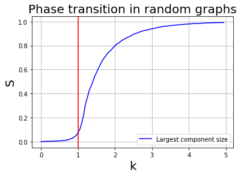

```python
plt.figure()
plt.plot(vk,S,'b', label='Largest component size')
plt.xlabel("k", fontsize=20)
plt.ylabel("S", fontsize=20)
plt.title("Phase transition in random graphs", fontsize=20)
plt.axvline(x=1, color = 'r')
plt.grid(True)
plt.legend()
plt.show();
```

We can see that, on average, the curve is smooth and the critical point happens to be at $\langle{k}\rangle=1$, as expected analitically. The discontinuity at $\langle{k}\rangle=1$ is more accurate as N (number of nodes) increases.

Before $\langle{k}\rangle = 1$, the connected nodes are spread out on the network, and no gigant component can be seen. After the average degree was set to be 1, the sparsely connected nodes starts to connect with each other, suddenly causing the largest component to grow.

And also, for verifying the small world property, we must see the dependency of

$$ d_{max} = \frac{log N}{log \langle{k}\rangle} $$

This dependency comes from considering that the distance from a node i scales as follows:

At distance d=1, i-th node has $\langle{k}\rangle$ connected nodes

At distance d=2, i-th node has $\langle{k}\rangle^2$ connected nodes

At distance d=3, i-th node has $\langle{k}\rangle^3$ connected nodes

$\vdots$

At distance d=d, i-th node has $\langle{k}\rangle^d$ connected nodes

Therefore, the number of nodes at distance $d$ from node i is given by

$$ \begin{equation} N(d) \approx \sum_{l=0}^d \langle{k}\rangle^l = \frac{\langle{k}\rangle^{d+1} - 1}{\langle{k}\rangle - 1} \end{equation} $$

And we have that the maximum distance (Network\'s diameter) is given by

$$ \begin{equation} N = \langle{k}\rangle^d_{max} \end{equation} $$

and

$$ \begin{equation} d_{max} = \frac{log(N)}{log(\langle{k}\rangle)} \end{equation} $$

For this purpouse, we can analyse how the average shortest path length and the diameter changes with the number of nodes

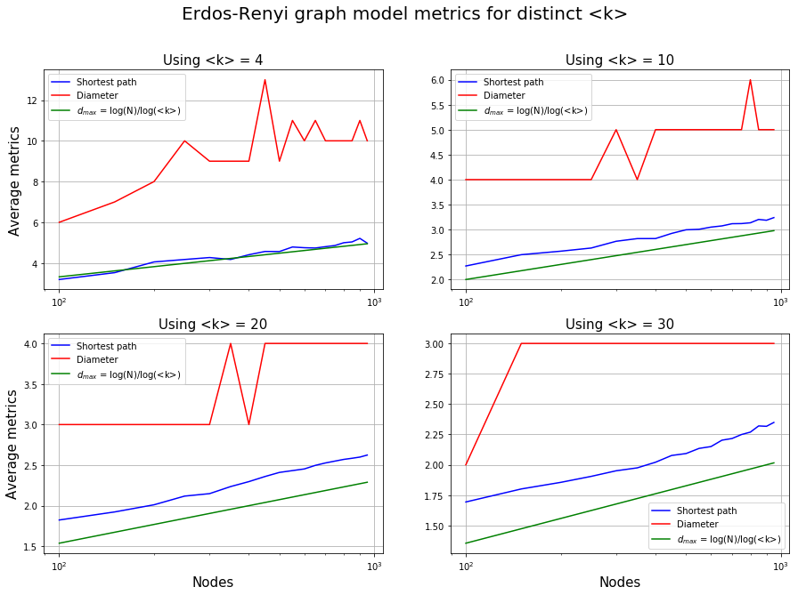

```python
N = np.arange(100, 1000, 50)
avg_k = [4, 10, 20, 30]

plt.figure(1, figsize=(15,10))
plt.suptitle('Erdos-Renyi graph model metrics for distinct <k>', fontsize=20)


count = 1
for k in avg_k:

    avg_sp = []
    avg_diam = []
    dmax = []

    for n in N:
        p = k/n
        G = nx.fast_gnp_random_graph(n, p, seed=None, directed=False)
        G = G.to_undirected()
        G.remove_edges_from(G.selfloop_edges())
        Gcc = sorted(nx.connected_component_subgraphs(G), key = len, reverse=True)
        G = Gcc[0]

        l = nx.average_shortest_path_length(G)
        avg_sp.append(l)

        d = nx.diameter(G)
        avg_diam.append(d)

        dmax.append(np.log(n)/np.log(k))

    plt.subplot(2,2,count)
    plt.title('Using <k> = {}'.format(avg_k[count-1]), fontsize=15)
    plt.semilogx(N, avg_sp, 'b', label='Shortest path', )
    plt.semilogx(N, avg_diam, 'r', label='Diameter')
    plt.semilogx(N, dmax, 'g', label='$d_{max}$ = log(N)/log(<k>)')

    if count == 1 or count == 3:
        plt.ylabel("Average metrics", fontsize=15)

    if count== 3 or count == 4:
        plt.xlabel("Nodes", fontsize=15)

    plt.grid(True)

    plt.legend()


    count+=1

plt.show()
```

# Question 3

Now we will show the most import property of small world networks. Once we can alter the rewiring probability $p$, it happens to exist a distinct behavior between the average shortest path length and the clustering coefficient, as mentioned on previous questions. Therefore, there is a value for $p$ that maximizes the clustering coefficient while minimizes the average shortest path length.

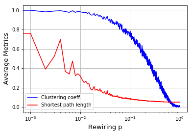

```python
N = 800
av_degree = 8
k = int(av_degree/2)
qMax = 1
qSteps = 0.001
qTotal = int(qMax/qSteps)
n = 10

vcc = np.zeros(qTotal)
vl = np.zeros(qTotal)
vq = np.arange(0, qMax, qSteps)

count = 0
for q in vq: #q is the rewiring probability
    G = nx.watts_strogatz_graph(N, k, q, seed=None)
    cc = nx.average_clustering(G)
    vcc[count]+=cc/n
    l = nx.average_shortest_path_length(G)
    vl[count]+=l/n
    count+=1

plt.figure()
plt.semilogx(vq,np.array(vcc)/max(vcc),'b', label='Clustering coeff.')
plt.semilogx(vq,np.array(vl)/max(vl),'r', label='Shortest path length')

plt.ylabel('Average Metrics', fontsize=13)
plt.xlabel("Rewiring p", fontsize=13)
plt.legend()
plt.grid(True)
plt.show();
```

```python
N = 100
av_degree = 8
k = int(av_degree/2)
qMax = 1
qSteps = 0.001
qTotal = int(qMax/qSteps)

vsec_mom = np.zeros(qTotal)
vq = np.arange(0, qMax, qSteps)

n = 50
for i in range(n):

    count = 0
    for q in vq: #q is the rewiring probability
        G = nx.watts_strogatz_graph(N, k, q, seed=None)

        secmom = moment_degree(G, 2)
        vsec_mom[count] += secmom/n
        count+=1

plt.figure()
plt.plot(vq, vsec_mom,'b-')
plt.xlabel("Rewiring probability p", fontsize=13)
plt.ylabel("Second moment", fontsize=13)
plt.title("Small-world networks", fontsize=15)
plt.legend()
plt.grid(True)
plt.show();
```

[output not shown]

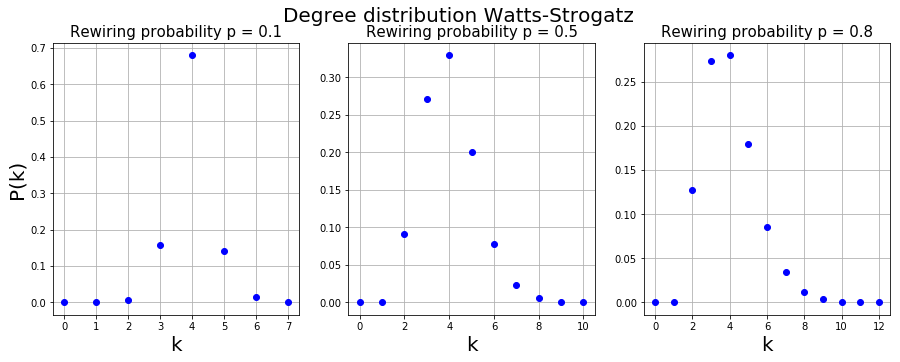

```python
plt.figure(1, figsize=(15,5))
plt.suptitle('Degree distribution Watts-Strogatz\n\n\n', fontsize=20)

N = 10000
av_degree = 8
k = int(av_degree/2)

plt.subplot(1,3,1)
plt.title('Rewiring probability p = 0.1', fontsize=15)

G = nx.watts_strogatz_graph(N, k, 0.1, seed=None)
ks, pk = degree_distribution(G)

plt.plot(ks, pk, 'bo')
plt.xlabel('k', fontsize=20)
plt.ylabel('P(k)', fontsize=20)
plt.grid(True)

plt.subplot(1,3,2)
plt.title('Rewiring probability p = 0.5', fontsize=15)

G = nx.watts_strogatz_graph(N, k, 0.5, seed=None)
ks, pk = degree_distribution(G)

plt.plot(ks, pk, 'bo')
plt.xlabel('k', fontsize=20)
plt.grid(True)

plt.subplot(1,3,3)
plt.title('Rewiring probability p = 0.8', fontsize=15)
G = nx.watts_strogatz_graph(N, k, 0.8, seed=None)
ks, pk = degree_distribution(G)

plt.plot(ks, pk, 'bo')
plt.xlabel('k', fontsize=20)
plt.grid(True)

plt.show()
```

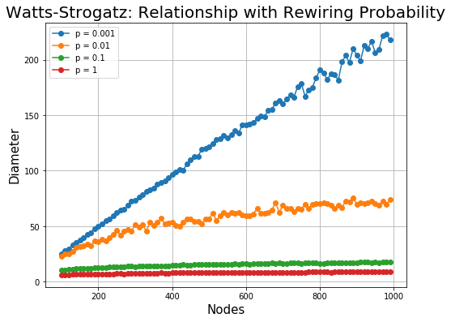

```python
N = np.arange(100, 1000, 10)
av_degree = 8
k = int(av_degree/2)
T = 30

p_all = [0.001, 0.01, 0.1, 1]

plt.figure(1, figsize=(8,6))
plt.title('Watts-Strogatz: Relationship with Rewiring Probability', fontsize=20)

for p in p_all:

    avg_diam = np.zeros(len(N))

    count = 0
    for n in tqdm(N):
        for t in range(T):
            G = nx.watts_strogatz_graph(n, k, p, seed=None)
            G = G.to_undirected()
            G.remove_edges_from(G.selfloop_edges())
            Gcc = sorted(nx.connected_component_subgraphs(G), key = len, reverse=True)
            G = Gcc[0]

            d = nx.diameter(G)
            avg_diam[count]+=d/T
        count+=1

    plt.plot(N, avg_diam, marker='o' ,label='p = {}'.format(p))

plt.xlabel("Nodes", fontsize=15)
plt.ylabel("Diameter", fontsize=15)
plt.grid(True)

plt.legend()

plt.show()
```

Bythis last plot, it is clearer the influence of the rewiring probability $p$ on Watts-Strogatz network models. As $p$ is closer to zero, the nodes are only linked to their nearest neighbors, causing the diameter to increase approximately linearly with the increment of the number of nodes. As $p$ increases, shortcuts are created and the diameter itself reduces.

# Question 4

Now we aim to compare the Barabasi-Albert with the Configuration Model network. This last model consists on the attempt to generate random networks with some desired distribution for probability degree. That is, given that we want a network with a binomial, exponential, poisson, ... probability distribution for the degree, how do we build a network with this property?

The algorithm consideres that for each node we assign a previously determined degree and connects them at random. With this model, we can also generate 'child networks' with the same degree distribution of their parents, which makes possible the study of dynamical process for multiple networks with the same degree characteristic.

```python
N = 1000
av_degree = 10
n = 30
m = int(av_degree/2)
means_GBA = metrics_mean('GBA', N, av_degree, n, p, m=m)

means_CM = metrics_mean('GCM', N, av_degree, n, exp=3)
```

```python
print('\tBarabasi-Albert\tConfiguration Model')
print('N\t', '%.2f'%means_GBA[0], '\t%.2f'%means_CM[0])
print('AVG_K\t', '%.5f'%means_GBA[1], '\t%.5f'%means_CM[1])
print('SECMOM\t', '%.5f'%means_GBA[2], '\t%.5f'%means_CM[2])
print('AVG_SP\t', '%.5f'%means_GBA[3], '\t%.5f'%means_CM[3])
print('AVG_CC\t', '%.5f'%means_GBA[4], '\t%.5f'%means_CM[4])
print('TRANSIT\t', '%.5f'%means_GBA[5], '\t%.5f'%means_CM[5])
print('ASSORT\t', '%.5f'%means_GBA[6], '\t%.5f'%means_CM[6])
```

```
	Barabasi-Albert	Configuration Model
N	 1000.00 	470.67
AVG_K	 7.96800 	2.15962
SECMOM	 138.05533 	21.03472
AVG_SP	 3.18494 	6.09299
AVG_CC	 0.03540 	0.00515
TRANSIT	 0.02426 	0.00567
ASSORT	 -0.06318 	-0.15581
```

Considering the above generated table, we can analyse via Number of nodes, SECond MOMment, AVeraGe Clustering Coefficient and ASSORTativity. All of them BA turns out to be higher than CM.

N: CM model with a power law distribution will attribute to most of its nodes a low degree. Once the degree for each individual node must be a natural number, at the tail of the distribution, all nodes will have no connections and, since we choose only the biggest component in order to get the diameter, most part of the nodes are cut off from the network, reducing their number. It does not happen on BA model, which considers all nodes to the network

SECMOM: The presence of a high number of nodes influences to the second moment. It is the variance and, as before mentioned, it is related to how much are the degrees spread out over the degree distribution. Since CM have less nodes with a power law distribution (which is the same distribution as expected to the BA model), they will be less spread out when compared to BA model.

AVG_CC: By the preferential attachment presence on BA model, the formation of clusters (neighbor triangles), even though smaller than other networks (ER, for instance), is higher than CM, which has their edges connected at random, with no preferential attachment.

ASSORT: Once it predicts the correlation between a node's degree and the degree of it neighbors, the table shows us that CM model has more nodes with high degree that connects to ones with lower degree than BA model. It can also be explain by the randomness of CM model, without the preferential attachment in BA. Despite of having high degree nodes connecting to lower ones, BA still tends to form more connected hubs than CM, increasing the assortativenness.

Finally, a submodel of BA is the nonlinear Barabasi model, which we will consider for this exercise. For nonlinear preferential attachment we consider a coefficient $\alpha$ such that

$$ \begin{equation} P(k_i) = \frac{k_i^{\alpha}}{\sum_j k_j^{\alpha}} \end{equation} $$

as the probability to a new added node connects to the i-th older one. For $\alpha = 1$, we recover theBA standard model. Therefore we have now the possibility to have a sublinear preferential attachment ($0 < \alpha < 1$) and superlinear regime ($\alpha$ > 1).

```python
import igraph as ig
```

```python
N = np.arange(100, 1000, 50)

av_degree = 10
m = int(av_degree/2)

G = ig.Graph.Barabasi(N[0], m, power=2)
G.write_gml('/home/jorge/Documents/redes_complexas/igraph/graph.gml')
```

```python
def read_gml_and_Gcc(path, nodetype=int):
    """
    FUNCTION:
    Read a file gml type that contains node connections
    and their weights as float.

    PARAMETERS:
    path: file path as string located in computer

    RETURN:
    tuple: (pos, G), representing the position object
    (networkx as nx, spring_layout()) for draw purpose and
    the Graph G itself made from file
    """
    G = nx.read_gml(path, label='id')
    G = nx.convert_node_labels_to_integers(G, first_label=0)
    labels = G.nodes()
    pos = nx.spring_layout(G)
    G = G.to_undirected()
    G.remove_edges_from(G.selfloop_edges())
    Gcc = sorted(nx.connected_component_subgraphs(G), key=len, reverse=True)
    G = Gcc[0]
    return pos, G
```

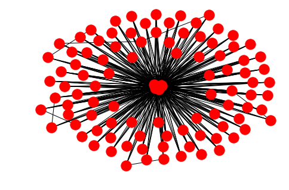

```python
pos, G = read_gml_and_Gcc('/home/jorge/Documents/redes_complexas/igraph/graph.gml')
nx.draw(G, pos=pos)
```

Now we can compare how does the highest degree on the network changes as we increases the time span (since at each time step we add one node to the network, time $t$ is linearly related to the number of nodes on the graph)

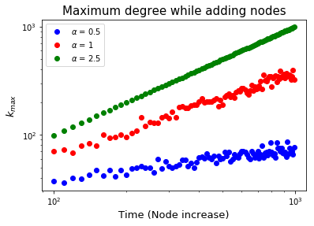

```python
N = np.arange(100, 1000, 10)

av_degree = 10
m = int(av_degree/2)
kMax1 = []
kMax2 = []
kMax3 = []
plt.title('Maximum degree while adding nodes', fontsize=15)
for n in tqdm(N):
    G = ig.Graph.Barabasi(n, m, power=0.5)
    G.write_gml('/home/jorge/Documents/redes_complexas/igraph/graph.gml')
    pos, G = read_gml_and_Gcc('/home/jorge/Documents/redes_complexas/igraph/graph.gml')

    vk = G.degree()
    vk = [node[1] for node in vk]
    vk.sort(reverse=True)
    kMax1.append(vk[0])

    G = ig.Graph.Barabasi(n, m, power=1)
    G.write_gml('/home/jorge/Documents/redes_complexas/igraph/graph.gml')
    pos, G = read_gml_and_Gcc('/home/jorge/Documents/redes_complexas/igraph/graph.gml')

    vk = G.degree()
    vk = [node[1] for node in vk]
    vk.sort(reverse=True)
    kMax2.append(vk[0])

    G = ig.Graph.Barabasi(n, m, power=2.5)
    G.write_gml('/home/jorge/Documents/redes_complexas/igraph/graph.gml')
    pos, G = read_gml_and_Gcc('/home/jorge/Documents/redes_complexas/igraph/graph.gml')

    vk = G.degree()
    vk = [node[1] for node in vk]
    vk.sort(reverse=True)
    kMax3.append(vk[0])

plt.loglog(N, kMax1, 'bo', label='$\\alpha$ = 0.5')
plt.loglog(N, kMax2, 'ro', label='$\\alpha$ = 1')
plt.loglog(N, kMax3, 'go', label='$\\alpha$ = 2.5')
plt.xlabel('Time (Node increase)', fontsize=13)
plt.ylabel('$k_{max}$', fontsize=13)
plt.legend()
plt.show()
```

# Question 5

For this last question we will study the relation between real world networks and the ER, WS, BA models through PCA analysis. This will be done varying the controlable parameters for each model, get the statistical metrics: mean, standard deviation, second moment and entropy for the distributions of degree, closenness centrality, betweenness centrality, eigenvector centrality, PageRank, K-core and random walk accessibility and reduce the matrix into a 2D plot using PCA.

Firstly we need to build a function to calculate the random walk accessibility (not implemented)

```python
def build_transit_probab_matrix(G):
    """
    FUNCTION:
    Build the Transition Probability Matrix

    PARAMETERS:
    G: networkx graph object

    RETURN:
    numpy matrix 2x2: Transition probability matrix address
    """

    #Firstly, we can build a null vector in order to store
    #each element from our probability matrix
    adj_matrix = nx.to_numpy_matrix(G, nodelist=list(G.nodes()))
    total_nodes = len(adj_matrix)
    P_matrix = np.zeros((total_nodes, total_nodes))

    #These loop will set the principal diagonal as zero
    #and divide all other elements byt the sum of each
    #row (normalizing each of them)
    for i in range(total_nodes):
        for j in range(total_nodes):
            if adj_matrix[i,j] == 0:
                P_matrix[i,j] = 0
            else:
                P_matrix[i,j] = adj_matrix[i,j]/np.sum(adj_matrix[i])
    return P_matrix
```

```python
def accessibility(G):
    """
    FUNCTION:
    Calculates the nodes accessibility of a graph ia
    matrix exponential

    PARAMETERS:
    G: networkx graph object

    RETURN:

    """
    import scipy.linalg as alg
    N = len(G.nodes())
    P = build_transit_probab_matrix(G)

    P2 = alg.expm(P)/np.exp(1)
    vacc = np.zeros(N, dtype=float)
    for i in np.arange(0, N):
        acc = 0
        for j in np.arange(0, N):
            if P2[i,j] > 0:
                acc += P2[i,j]*np.log(P2[i,j])

        acc = np.exp(-acc)
        vacc[i] = acc
    return vacc
```

Now we need to calculate each distribution for the network metrics desired. That is, for a given network, degree, closenness centrality, etc. must be calculated. For this purpouse, we can build a function to perform this task

```python
def build_matrix_correl(G):
    """
    FUNCTION
    Calculate several measurements to facilitate their comparison in a correlation matrix

    PARAMETERS:
    G: networkx graph object

    RETURN:
    pandas-library dataframe object containing
    {'K':vk,'CLC':CLC,'B':B,'EC':EC,'PR':PR,'KC':KC, 'ACC':ACC},
    which stands for the distributions of:
    K   - degree
    CLC - clustering coefficient
    B   - Betweenness centrality
    EC  - Eigenvector centrality
    PR  - PageRank
    KC  - Core number
    ACC - Random Walk Accessibility
    """
    vk = dict(G.degree())
    vk = list(vk.values())

    CLC = dict(nx.closeness_centrality(G))
    CLC = list(CLC.values())

    B = dict(nx.betweenness_centrality(G))
    B = list(B.values())

    EC = dict(nx.eigenvector_centrality(G, max_iter=1000))
    EC = list(EC.values())

    PR = dict(nx.pagerank(G, alpha=0.85))
    PR = list(PR.values())

    KC = dict(nx.core_number(G))
    KC = list(KC.values())

    ACC = accessibility(G)

    df = pd.DataFrame({'K':vk,'CLC':CLC,'B':B,'EC':EC,'PR':PR,'KC':KC, 'ACC':ACC})
    #print(df.head())
    return df
```

After join all metrics into a pandas dataframe, we need a funtion to calculate the statistical metrics for each distribution.

```python
def distribution_metrics(dataFrame):
    """
    FUNCTION:
    Determines some statistical metrics associated to each network measurement that is related to each node. In
    other words, given some measurements distributions, it calculates statistical relavant parameters of them

    PARAMETERS:
    dataFrame: pandas DataFrame object

    ex:
    dataFrame = {'EC':EC, 'BC':BC}
    where  'EC' stands for Eigenvector Centrality with type(EC) = list;
           'BC' stands for Betweenness Centrality with type(BC) = list


    RETURN:
    list all_metrics: list of each statistical metrics calculated
    """
    all_metrics = []
    for i in dataFrame:
        metrics = []
        metrics.append(np.mean(dataFrame[i]))

        metrics.append(np.std(dataFrame[i]))

        metrics.append(stats.moment(dataFrame[i], moment=2))

        metrics.append(stats.entropy(dataFrame[i]))

        all_metrics.append(metrics)
    return all_metrics
```

Lastly, we need a function to vary the controlable parameters and generate the network and statistical measurements (using the two last mentioned functions). That is, for ER model, we can start from $p = 0.5$ and, at each incremento of $\Delta p = 0.05$, we extract the statistical metrics; for WS model, we can start from $p = 0.3$ and increment the same $\Delta p$; and for BA, we can start from $\alpha = 0.1$, for sublinear and from $\alpha = 2$, for superliner preferential attachment, increasing by $\Delta \alpha = 0.1$.

```python
def network_variations_PCA(G, G_type, all_metrics, N, n, p, k, power=1, igraph=False):
    if igraph == False:
        dataFr = build_matrix_correl(G)
        all_metrics.append(distribution_metrics(dataFr))

        vk = dict(G.degree())
        vk = list(vk.values())
        if sum(vk)%2 != 0:
            vk[0]+=1

        if G_type == 'WS':

            for i in range(n):
                #print('WS', p)
                p+=0.05
                G = nx.watts_strogatz_graph(N, k, p)

                dataFr = build_matrix_correl(G)
                all_metrics.append(distribution_metrics(dataFr))

        else:
            for i in range(n):
                #print('ER', p)
                p+=0.05
                G = nx.fast_gnp_random_graph(N, p, seed=None, directed=False)

                dataFr = build_matrix_correl(G)
                all_metrics.append(distribution_metrics(dataFr))

    else:
        G.write_gml('/home/jorge/Documents/redes_complexas/igraph/graph.gml')
        pos, G = read_gml_and_Gcc('/home/jorge/Documents/redes_complexas/igraph/graph.gml')
        dataFr = build_matrix_correl(G)
        all_metrics.append(distribution_metrics(dataFr))

        for i in range(n):
            #print('BA', power)
            power+=0.1
            G = ig.Graph.Barabasi(n, m=k, power=power)
            G.write_gml('/home/jorge/Documents/redes_complexas/igraph/graph.gml')
            pos, G = read_gml_and_Gcc('/home/jorge/Documents/redes_complexas/igraph/graph.gml')

            dataFr = build_matrix_correl(G)
            all_metrics.append(distribution_metrics(dataFr))
```

```python
all_metrics = []

N = 500
av_degree = 8
k = int(av_degree/2)
p = 0.5
n = 9

##########
G = nx.fast_gnp_random_graph(N, p, seed=None, directed=False)
network_variations_PCA(G, 'ER', all_metrics, N, n, p, k)
print('ER Done!')
##########
p = 0.3
G = nx.watts_strogatz_graph(N, k, p)
network_variations_PCA(G, 'WS', all_metrics, N, n, p, k)
print('WS Done!')
##########
power = 0.1
G = ig.Graph.Barabasi(n, m=k, power=power)
network_variations_PCA(G, 'BA', all_metrics, N, n, p, k, power=power, igraph=True)
print('BA Done!')
##########
power = 2
G = ig.Graph.Barabasi(n, m=k, power=power)
network_variations_PCA(G, 'BA', all_metrics, N, n, p, k, power=power, igraph=True)
print('BA Done!')
```

```
ER Done!
WS Done!
BA Done!
BA Done!
```

Finally we must read our desired real-world networks and perform the same process as before.

```python
def read_txt_and_Gcc(path, comment='%', nodetype=int):
    """
    FUNCTION:
    Read a file that contains node connections and their
    weights as float. Example of readable file
    ---------
    %This is an example file.
    %NodeA NodeB Weight
    0 1 0.5
    1 3 2.0
    2 3 1.2
    ---------

    Comments can be marked as wish ('%' is set as default)

    PARAMETERS:
    path: file path as string located in computer
    comment: char (or string) used in file to mark comments

    RETURN:
    tuple: (pos, G), representing the position object
    (networkx as nx, spring_layout()) for draw purpose and
    the Graph G itself made from file
    """
    G = nx.read_edgelist(path, comments=comment, nodetype=nodetype, data=(('weight', float),))
    G = nx.convert_node_labels_to_integers(G, first_label=0)
    labels = G.nodes()
    pos = nx.spring_layout(G)
    G = G.to_undirected()
    G.remove_edges_from(G.selfloop_edges())
    Gcc = sorted(nx.connected_component_subgraphs(G), key=len, reverse=True)
    G = Gcc[0]
    return pos, G
```

```python
pos_euro, G_euroroad = read_txt_and_Gcc('/home/jorge/Documents/redes_complexas/subelj_euroroad/out.subelj_euroroad_euroroad')

G_celegans = nx.Graph()
pos_celegans, G_celegans = read_gml_and_Gcc('/home/jorge/Documents/redes_complexas/celegansneural/celegansneural.gml')
G_celegans = nx.Graph(G_celegans)

pos_usair, G_usair = read_txt_and_Gcc('/home/jorge/Documents/redes_complexas/US_largest500_airportnetwork.txt')
```

```python
pos_power, G_power = read_txt_and_Gcc('/home/jorge/Documents/redes_complexas/data/powergrid.txt')

pos_protein, G_protein = read_txt_and_Gcc('/home/jorge/Documents/redes_complexas/data/ppi.maayan-vidal.txt')
```

```python
dataFr = build_matrix_correl(G_euroroad)
all_metrics.append(distribution_metrics(dataFr))

dataFr = build_matrix_correl(G_celegans)
all_metrics.append(distribution_metrics(dataFr))

dataFr = build_matrix_correl(G_usair)
all_metrics.append(distribution_metrics(dataFr))
```

```python
dataFr = build_matrix_correl(G_power)
all_metrics.append(distribution_metrics(dataFr))

dataFr = build_matrix_correl(G_protein)
all_metrics.append(distribution_metrics(dataFr))
```

```python
len(all_metrics)
```

```
45
```

[figure not shown]

```python
from sklearn.decomposition import PCA
pca = PCA(n_components=1)

fig = plt.figure(figsize=(5,5))
plt.suptitle('Principal Component Analysis (PCA)', fontsize=15)

for i in range(len(all_metrics)):
    x = pca.fit_transform(all_metrics[i])
    x = np.transpose(x)

#     if i == 0:
#         plt.plot(x[:, 0], x[:, 1], 'b*', label='ER, p = 0.1')
#         plt.legend()

#     elif i < 10 and i > 0:
#         plt.plot(x[:, 0], x[:, 1], 'bo')

    if i == 10:
        plt.plot(x[:, 0], x[:, 1], 'g*', label='WS, p = 0.1')
        plt.legend()

    elif i < 20 and i > 10:
        plt.plot(x[:, 0], x[:, 1], 'go')

    elif i == 20:
        plt.plot(x[:, 0], x[:, 1], 'r*', label='BAsub, $\\alpha$ = 0.1')
        plt.legend()

    elif i < 30 and i > 20:
        plt.plot(x[:, 0], x[:, 1], 'ro')
        plt.legend()

    elif i == 30:
        plt.plot(x[:, 0], x[:, 1], 'k*', label='BAsuper, $\\alpha$ = 2')
        plt.legend()

    elif i < 40 and i > 30:
        plt.plot(x[:, 0], x[:, 1], 'ko')
        plt.legend()

    elif i == 40:
        plt.plot(x[:, 0], x[:, 1], 'x', label='Euroroad')
        plt.legend()

#     elif i == 41:
#         plt.plot(x[:, 0], x[:, 1], '+', label='C. elegans')
#         plt.legend()

#     elif i == 42:
#         plt.plot(x[:, 0], x[:, 1], 'd', label='US airport')
#         plt.legend()

    elif i == 43:
        plt.plot(x[:, 0], x[:, 1], 'x', label='Power grid')
        plt.legend()

#     elif i == 44:
#         plt.plot(x[:, 0], x[:, 1], 'x', label='Protein')
#         plt.legend()

plt.xlabel('First principal component', fontsize=13)
plt.ylabel('Second principal component', fontsize=13)
plt.show()
```

[figure not shown]

```python
fig = plt.figure(figsize=(5,5))
plt.suptitle('Principal Component Analysis (PCA)', fontsize=15)

for i in range(len(all_metrics)):
    x = pca.fit_transform(all_metrics[i])
    x = np.transpose(x)

    if i == 0:
        plt.plot(x[:, 0], x[:, 1], 'b*', label='ER, p = 0.1')
        plt.legend()

    elif i < 10 and i > 0:
        plt.plot(x[:, 0], x[:, 1], 'bo')

#     if i == 10:
#         plt.plot(x[:, 0], x[:, 1], 'g*', label='WS, p = 0.1')
#         plt.legend()

#     elif i < 20 and i > 10:
#         plt.plot(x[:, 0], x[:, 1], 'go')

#     elif i == 20:
#         plt.plot(x[:, 0], x[:, 1], 'r*', label='BAsub, $\\alpha$ = 0.1')
#         plt.legend()

#     elif i < 30 and i > 20:
#         plt.plot(x[:, 0], x[:, 1], 'ro')
#         plt.legend()

#     elif i == 30:
#         plt.plot(x[:, 0], x[:, 1], 'k*', label='BAsuper, $\\alpha$ = 2')
#         plt.legend()

#     elif i < 40 and i > 30:
#         plt.plot(x[:, 0], x[:, 1], 'ko')
#         plt.legend()

#     elif i == 40:
#         plt.plot(x[:, 0], x[:, 1], 'x', label='Euroroad')
#         plt.legend()

    elif i == 41:
        plt.plot(x[:, 0], x[:, 1], '+', label='C. elegans')
        plt.legend()

    elif i == 42:
        plt.plot(x[:, 0], x[:, 1], 'd', label='US airport')
        plt.legend()

#     elif i == 43:
#         plt.plot(x[:, 0], x[:, 1], 'x', label='Power grid')
#         plt.legend()

    elif i == 44:
        plt.plot(x[:, 0], x[:, 1], 'x', label='Proteome')
        plt.legend()

plt.xlabel('First principal component', fontsize=13)
plt.ylabel('Second principal component', fontsize=13)
plt.show()
```

With those results, we can conclude that when considering all those network measurements and their associated statistical characteristics:

- Euroroad has characteristics that closer resembles WS model and higher sublinear preferential attachment BA model;
- Power grid closer resembles the sublinear and lower superlinear preferential attachment BA model;
- C. elegans, Human proteome and US airport closer resembles the ER model with lower probability $p$

The two graphical representations where made in order to get better look into each network model. ER model is very distant from WS and BA model, and the representation were made clearer by splitting the graphic.